# Physical Characteristics of Prostate Tumors

### Background

> Our inquiry is in what ways the physical parameters of prostate cancer cell masses co-occur with morbidity and which do not; and furthermore, do some physical parameters cluster with others?

> Cancer kills ~600,000 people in the U.S. each year. It is one of the leading causes of death in both postindustrial and industrializing countries. It is therefore the subject of much concern and concerted effort to eradicate. Governmental agencies, health organizations, private organizations, private individuals and fundraisers are constantly funding academic laboratories and private businesses. Funding is needed because labs able to do the research possess world class scientists and instruments.

> Cancer is when cells become abnormal, successfully replicating, sometimes very quickly, without experiencing apoptosis (programmed cell death). These accumulate into a cancerous mass which affects healthy cells, tissues and organs in a deleterious fashion. Severity depends on where cancer is located and how aggressively it is growing. One of the worst outcomes of a cancer is that it could become metastatic, meaning cancer cells lift off their current substrate and use the body’s transport systems to move, reattaching in a new location. Often the blood stream is used for this.

> The leading cancer in men is prostate cancer, the risk of which increases significantly with age. The prostate is a gland that secretes nourishment for male gametes to make them more virile. Cancers are approached in diverse ways to eradicate or to make them appear later and later in life. Some scientists try to maintain hormonal balance to fight off the senescing effects of andropause, others study invasive surgery to make it as least damaging as possible, and others use radiation or chemotherapy. Attempts to stymy cancer can be described in two broad categories as prevention and treatment.

> Our project will use the given data to see what the correlations are between physical parameters of the cancerous mass and how these ultimately relate to the cancer being benign or morbid. If important correlations are found, then physicians may be able to make well thought out decisions on whether a cancer that is diagnosed needs more immediate attention than another. The data is from Kaggle found at https://www.kaggle.com/sajidsaifi/prostate-cancer

> The data set has 100 observations from 100 patients, and 10 variables, 8 of which are numeric, 1 being categorical and the other ID. The categorical variable is either morbid or benign. The 8 numeric variables measure radius, texture, perimeter, area, smoothness, compactness, symmetry and fractal dimension. Texture measures what kind of consistency the mass has and the nature of its surface. Compactness measures how dense the cancerous mass is. Fractal dimension measures how complicated the symmetrical mass is and from this can be inferred surface area.

> It would seem reasonable that given physical parameters, there could be some correlation between type of mass and whether it is benign or malignant. While not necessarily causative, it may be a way for physicians to gauge their treatment options. One important hypothesis going forward is that larger cancers should be more complicating to the tissue around it which could increase morbidity. Another is that larger cancers, and ones that have more fractal dimension, will have much more surface area and might therefore be greater contenders for increased metastatic cells, which again would likely increase morbidity.

# Analysis

## Differing Dimensions

### Radius

```
##
##  Welch Two Sample t-test
##
## data:  cancerm$radius and cancerb$radius
## t = -1.7464, df = 73.644, p-value = 0.08492
## alternative hypothesis: true difference in means is not equal to 0
## 95 percent confidence interval:
##  -3.7895509  0.2496528
## sample estimates:
## mean of x mean of y
##  16.17742  17.94737
```

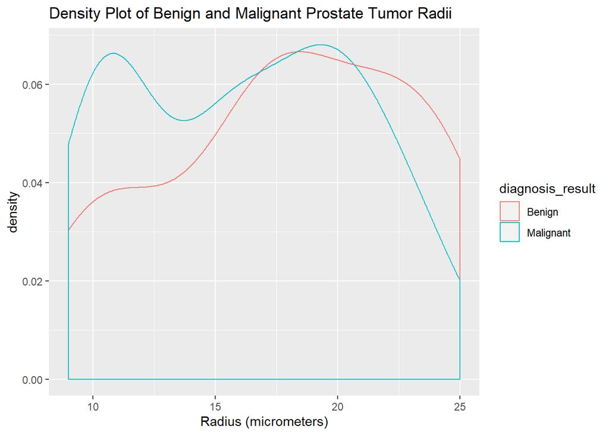

### Texture

There is no statistical difference present among the texture of malignant and benign tumors.

```
##
##  Welch Two Sample t-test
##
## data:  cancerm$texture and cancerb$texture
## t = 0.7031, df = 78.785, p-value = 0.4841
## alternative hypothesis: true difference in means is not equal to 0
## 95 percent confidence interval:
##  -1.378762  2.884704
## sample estimates:
## mean of x mean of y
##  18.51613  17.76316
```

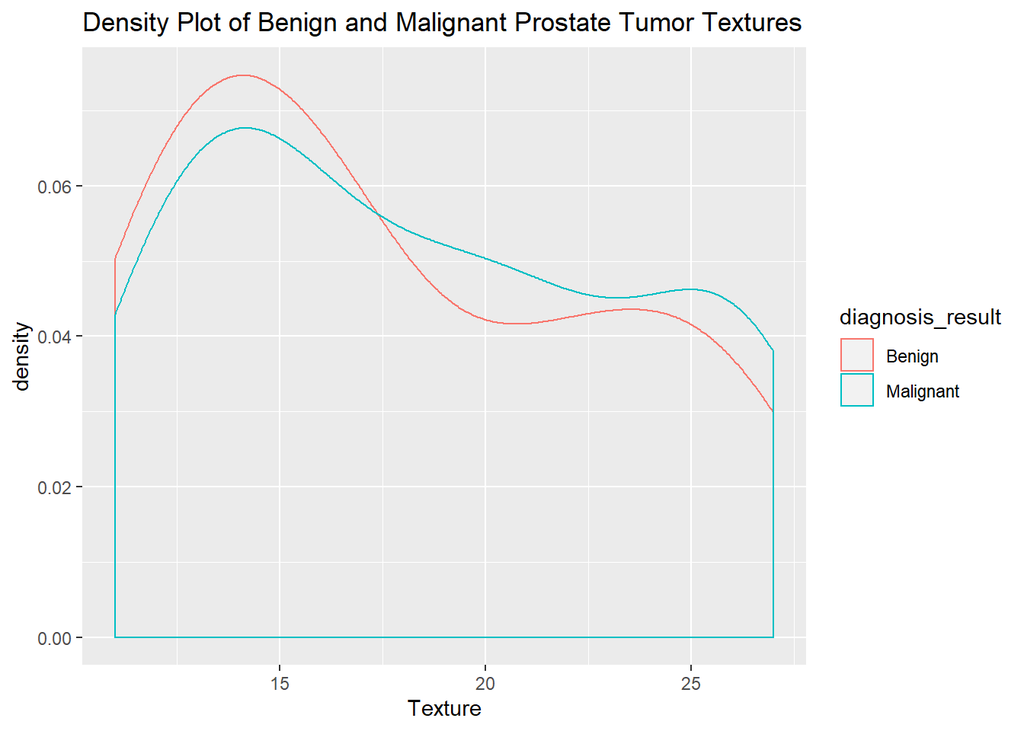

### Perimeter

A tumor’s perimeter differed in an extremely significant manner across the two diagnosis results. The p-value was p = 1.408e-11. This suggests that the perimeter of a tumor can be used to assist the diagnosis process.

```
##
##  Welch Two Sample t-test
##
## data:  cancerm$perimeter and cancerb$perimeter
## t = 7.7944, df = 85.624, p-value = 1.408e-11
## alternative hypothesis: true difference in means is not equal to 0
## 95 percent confidence interval:
##  21.96362 37.00412
## sample estimates:
## mean of x mean of y
##  107.9839   78.5000
```

When examining the distribution of perimeters between diagnosis results, one can see that malignant tumors have a significantly higher mean value, in addition to a right-skewed distribution. This suggests, that although the average perimeter of a malignant tumor is larger than the average perimeter of a benign tumor, the main difference comes in that the largest malignant tumors are considerably larger than the largest benign tumors.

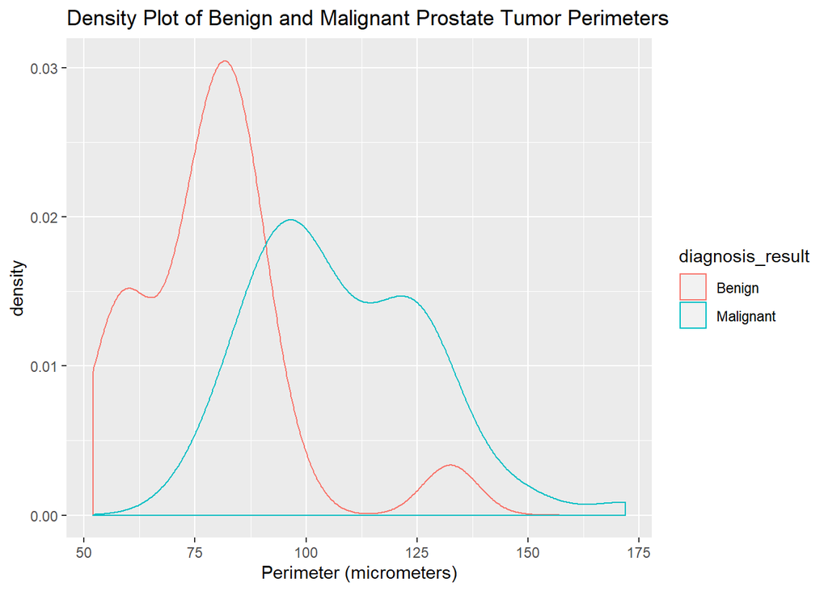

### Area

Due to their rapid growth, malignant tumors should be expected to have a significantly larger area. This is reflected in the p-value of this t-test being effectively 0.

```
##
##  Welch Two Sample t-test
##
## data:  cancerm$area and cancerb$area
## t = 7.1924, df = 93.558, p-value = 1.548e-10
## alternative hypothesis: true difference in means is not equal to 0
## 95 percent confidence interval:
##  266.8459 470.3731
## sample estimates:
## mean of x mean of y
##  842.9516  474.3421
```

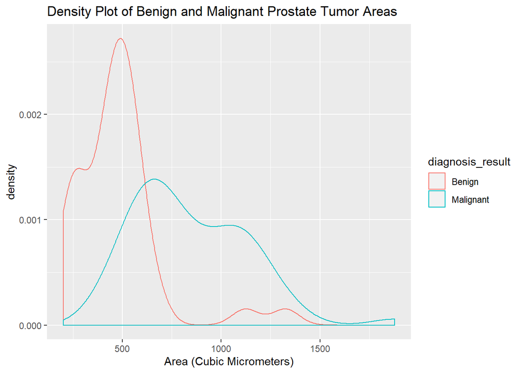

### Smoothness

Although the p-value generated is close to the typical $\alpha = .05$ signigance level, we choose not to reject the null hypothesis that the diagnoses have the same smoothness due to the data shown in the graph.

```
##
##  Welch Two Sample t-test
##
## data:  cancerm$smoothness and cancerb$smoothness
## t = 1.9545, df = 73.204, p-value = 0.05446
## alternative hypothesis: true difference in means is not equal to 0
## 95 percent confidence interval:
##  -0.000116613  0.011979092
## sample estimates:
##  mean of x  mean of y
## 0.10498387 0.09905263
```

This graph suggests no meaningful diagnoses could be drawn from the smoothness of a tumor as they share a similar mean value and range, with the only difference in smoothness coming from the right skew of malignant tumors, as compared to the left skew of benign tumors.

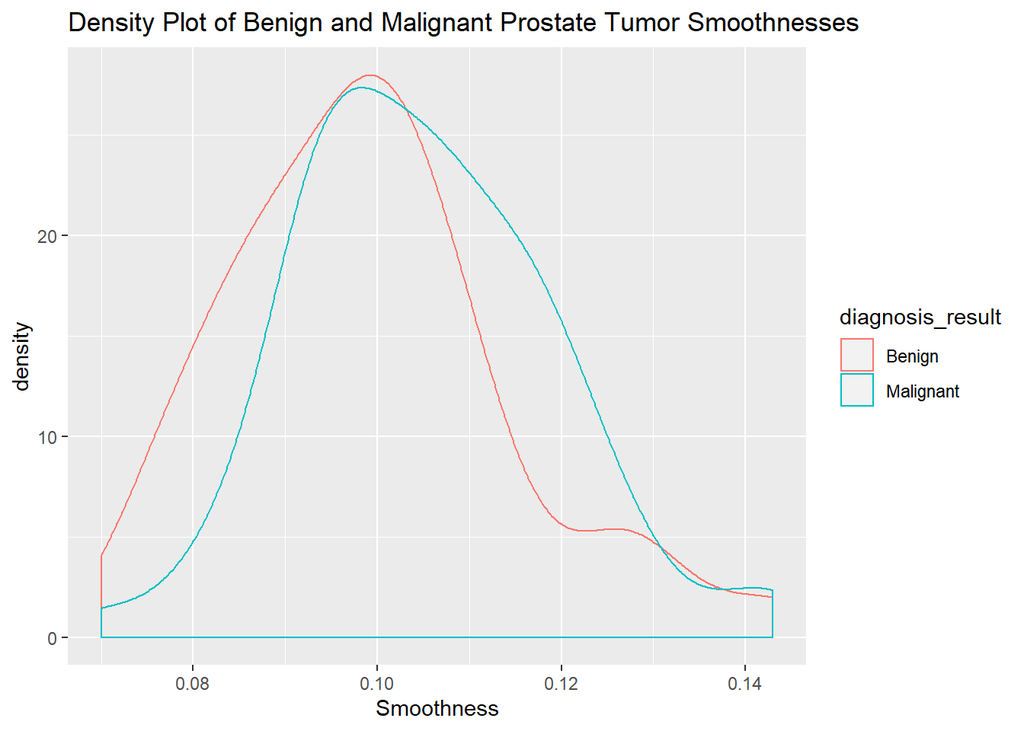

### Compactness

Compactness represents the density of a tumor and is a good proxy for how quick and unrestrained a malignant tumor can be. In this data, we see there is a probability of approximately 0 that malignant and benign share similar compactness.

```
##
##  Welch Two Sample t-test
##
## data:  cancerm$compactness and cancerb$compactness
## t = 6.3577, df = 94.91, p-value = 7.122e-09
## alternative hypothesis: true difference in means is not equal to 0
## 95 percent confidence interval:
##  0.04415406 0.08425001
## sample estimates:
##  mean of x  mean of y
## 0.15109677 0.08689474
```

The stark difference in compactness across diagnoses is explained in this chart, as one can see the large spike of density among the benign tumors below .1, in contrast to the large span of the malignant tumors above this value.

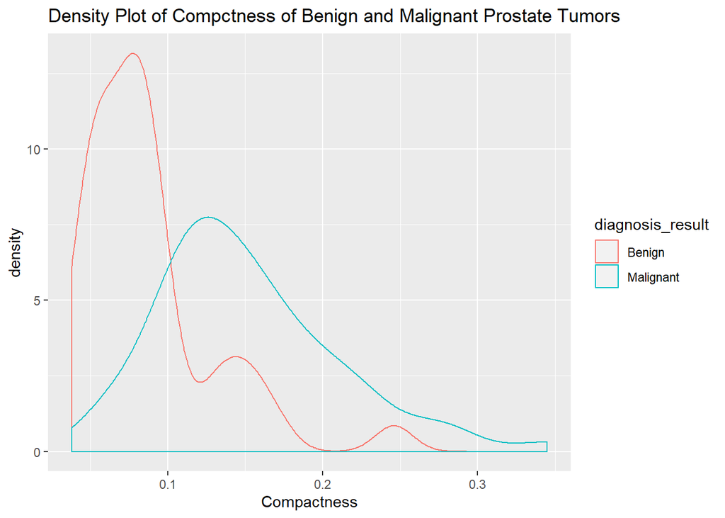

```r
ggplot(cancer)+
  geom_density(aes(x=compactness,color=diagnosis_result))+
  ggtitle('Density Plot of Compctness of Benign and Malignant Prostate Tumors')+
  xlab('Compactness')
```

### Symmetry

Symmetry is created by equvilant action of cell division in tumor growth. In a malignant tumor, the tumor grows rapidly and without restriction. This leads to the test shown where there is a 1.9% chance of the same symmetry.

```
##
##  Welch Two Sample t-test
##
## data:  cancerm$symmetry and cancerb$symmetry
## t = 2.3758, df = 78.779, p-value = 0.01994
## alternative hypothesis: true difference in means is not equal to 0
## 95 percent confidence interval:
##  0.002384725 0.027026141
## sample estimates:
## mean of x mean of y
## 0.1987581 0.1840526
```

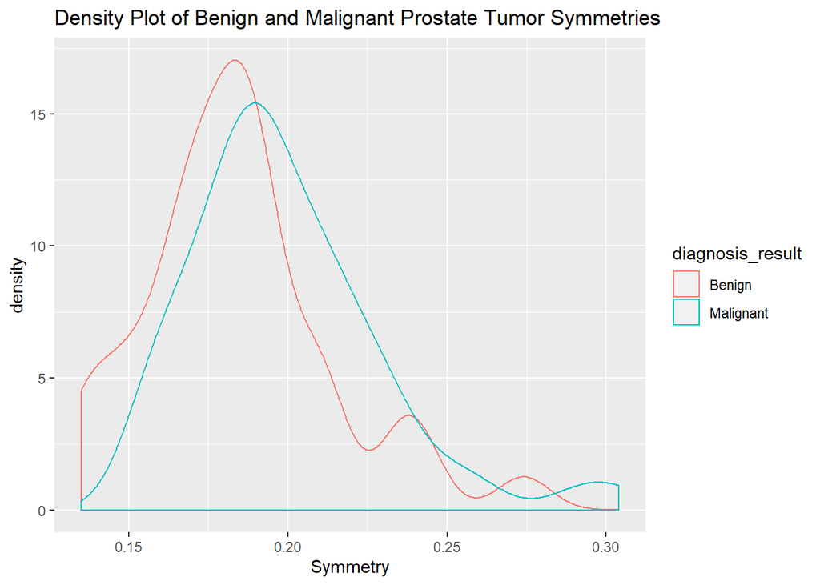

### Fractal Dimension

This trait shows the amount of complexity in the shape of the tumor. There is no difference in the statistical distribution of fractal dimension between malignant and benign tumors, meaning malignant tumors can not be identified by their visual chaos.

```
##
##  Welch Two Sample t-test
##
## data:  cancerm$fractal_dimension and cancerb$fractal_dimension
## t = 0.082453, df = 82.921, p-value = 0.9345
## alternative hypothesis: true difference in means is not equal to 0
## 95 percent confidence interval:
##  -0.003160214  0.003433559
## sample estimates:
##  mean of x  mean of y
## 0.06474194 0.06460526
```

The near identical density plots further solidify the similarity of fractal dimension across diagnosis results.

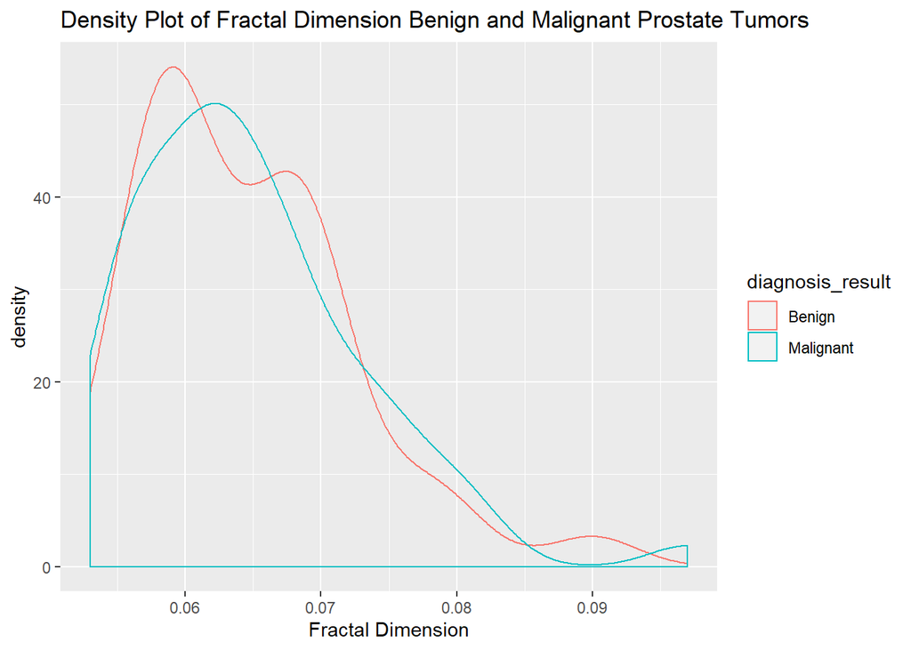

## Analysis Summary

> The following tabl summarizes the t tests done for every characteristic. As one can see, many tests produced low p values, however the characteristics showing the most obvious differences in malignant and benign tumors occur in perimeter, area, and compactness. Fractal Dimension and texture clearly show a lack of difference in these tests. Symmetry also displays a meaningful difference across the diagnosis results. Other traits such as smoothness and radius show low proababilities; however, examination of the distributions of these characteristics shows these traits would be ineffective for assisting diagnosis of prostate tumors.

```
## # A tibble: 8 x 5
##   Characteristic  `Benign Mean` `Malignant Mean` `Test Statistic` `P Value`
##   <chr>                   <dbl>            <dbl>            <dbl>     <dbl>
## 1 radius                17.9             16.2             -1.75    8.49e- 2
## 2 texture               17.8             18.5              0.703   4.84e- 1
## 3 perimeter             78.5            108.               7.79    1.41e-11
## 4 area                 474.             843.               7.19    1.55e-10
## 5 smoothness             0.0991           0.105            1.95    5.45e- 2
## 6 compactness            0.0869           0.151            6.36    7.12e- 9
## 7 symmetry               0.184            0.199            2.38    1.99e- 2
## 8 fractal_dimens~        0.0646           0.0647           0.0825  9.34e- 1
```

# Discussion

> Gernerally, in order to correctly diagnose whether the tumor is malignant or not, doctors have to use advanced medical instruments and take many examinations, both of which require time and money. So the motivation for us to pose this question is that we wonder if there are any physical parameters which could help us better diagnose whether a tumor is malignant or benign.

> Therefore, we observe some physical parameters of tumors and draw density plots to find if there are any patterns to draw conclusions.

> **?Qustion**The shortcoming of our analysis is we only take a single physical parameter each time, and did not consider whether the combination of some parameters will enlarge the difference between the malignant and the benign tumors. solution to new question: Firstly, we could put some physical parameters on the x-axis and another physical parameter on y axis to obeserve if there are any patterns to be teased out of the analysis. Secondly, we could use the fuction **Case_when()** to group some physical parameters in a group to observe if there are any patterns shown in the graphs.

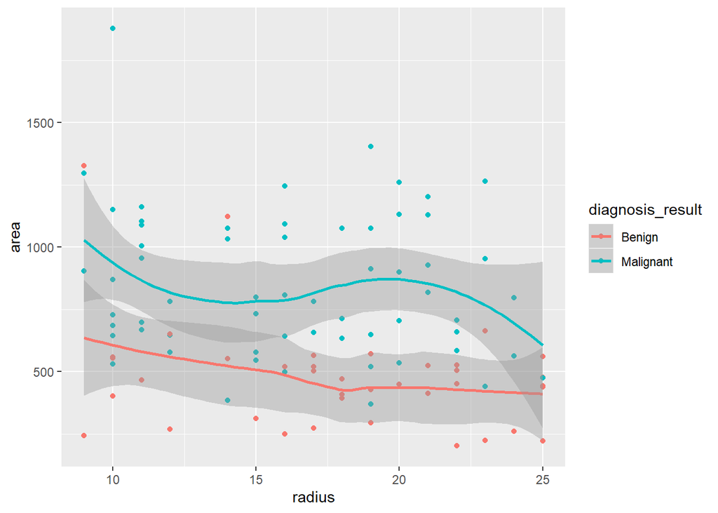

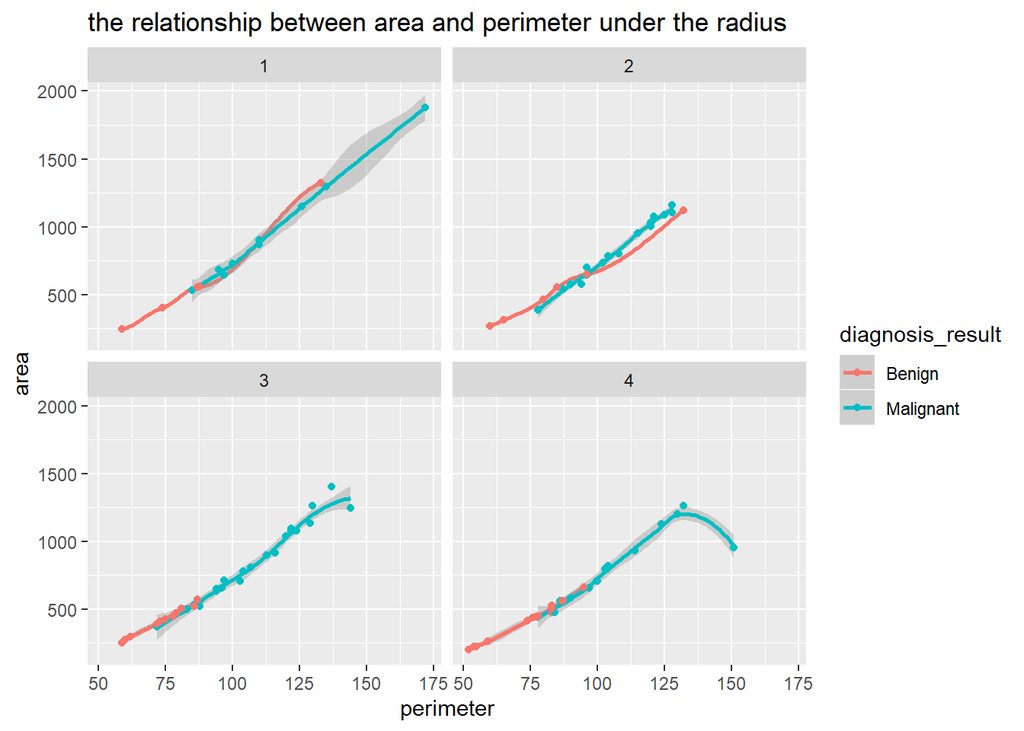

> Data Collection: We collect some data which is sorted by the ID of patients and the number is 100 which is a moderate sample size, large enough to fit in the Central Limit Theorem. Therefore, if we could have more data, we may better conclude and refice our summary and results. Besides, if we could get the information about the gender of the patients, we could find out whether the characteristics of tumors has something to do with the gender.